# Lab 1: Intro to R

Daniel Deneau

2021-06-05

```r
library(tidyverse)
library(openintro)
```

### Exercise 1

```r
arbuthnot$girls
```

```
##  [1] 4683 4457 4102 4590 4839 4820 4928 4605 4457 4952 4784 5332 5200 4910 4617
## [16] 3997 3919 3395 3536 3181 2746 2722 2840 2908 2959 3179 3349 3382 3289 3013
## [31] 2781 3247 4107 4803 4881 5681 4858 4319 5322 5560 5829 5719 6061 6120 5822
## [46] 5738 5717 5847 6203 6033 6041 6299 6533 6744 7158 7127 7246 7119 7214 7101
## [61] 7167 7302 7392 7316 7483 6647 6713 7229 7767 7626 7452 7061 7514 7656 7683
## [76] 5738 7779 7417 7687 7623 7380 7288
```

### Exercise 2

Overall there is a positive trend in the number of girl baptisms with a few periods of decline.

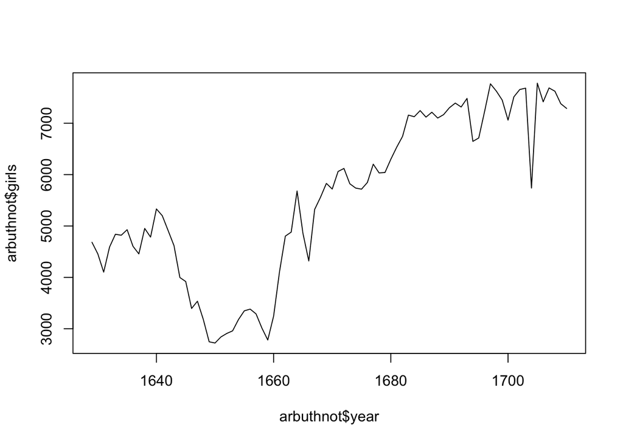

```r
plot(x = arbuthnot$year, y = arbuthnot$girls, type = "l")
```

### Exercise 3

There seems to be a very slight trend towards proportionally less boy baptisms throughout the years. Indicating that the gap between boy and girl baptisms decreased over time.

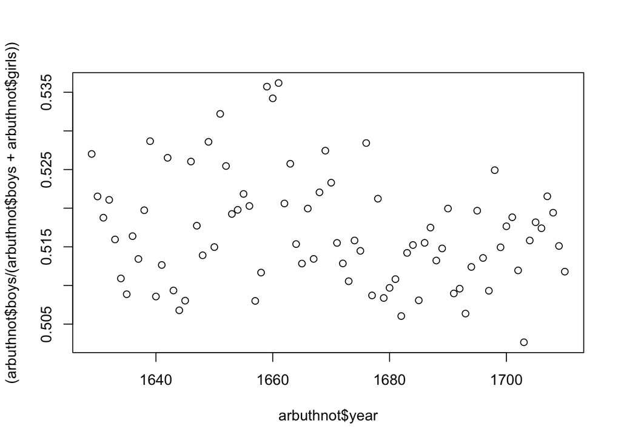

```r
plot(x = arbuthnot$year, y = (arbuthnot$boys / (arbuthnot$boys + arbuthnot$girls)))
```

### Exercise 4

The present dataset is 3 columns, year, boys, and girls, and has 63 entries. Each entry shows the year, number of boys born, and the number of girls born.

```r
dim(present)
```

```
## [1] 63  3
```

### OYO 1

The present set has a count of 63 with a scale in the millions, while the arbuthnot set has a count of 82, with a scale only in the thousands 17. The range of time in the present data set is 62 years, which is less than the 81 years in the arbuthnot set.

```r
count(present)
```

```
## # A tibble: 1 x 1
##       n
##   <int>
## 1    63
```

```r
count(arbuthnot)
```

```
## # A tibble: 1 x 1
##       n
##   <int>
## 1    82
```

### OYO 2

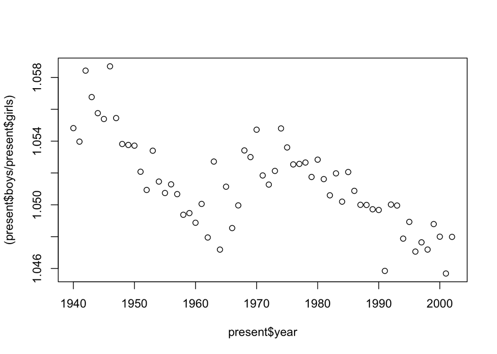

```r
plot(x = present$year, y = (present$boys / present$girls))
```

### OYO 3

The maximum number of total births, 4268326, was in 1961.

```r
max((present$boys + present$girls))
```

```
## [1] 4268326
```

```r
which.max((present$boys + present$girls))
```

```
## [1] 22
```

```r
present[22,]
```

```
## # A tibble: 1 x 3
##    year    boys   girls
##   <dbl>   <dbl>   <dbl>
## 1  1961 2186274 2082052
```